# Linear Regression_Pracice_HIV

2024-11-16

It is often the case that we need to linear and/or log transform data to be able to fit a linear model and enhance interpretation. Also In this exercise, we will consider three questions:  
1) How is the level of HIV RNA (a measure of the viral load in the bloodstream, exposure) associated with depression scores (outcome)  
2) Change of depression across age  
3) Level of HIV RNA and sex (female vs male)

In the file `HIV-eg_data.csv`, you have data from a sample of 5000 individuals with HIV. As this is a cross-sectional study, we are only able to examine associations and will not be able to determine causation (that is, our regression model can only test whether “x and y are associated” but not whether “x affects y”, without temporal relationship that cannot be achieved if not generated by cohort (longitudinal) data collection).

Get Data and prepare variables

```r
hiv <- read.csv("https://raw.githubusercontent.com/hiroshimamiya/EPIB607/refs/heads/main/Data/HIV_eg_data.csv")


hiv$age <- (rbeta(nrow(hiv),2,4)*30+20) + log(hiv$RNA)
hiv$ageGroup <- as.factor(cut(hiv$age, breaks=c(0, 20, 35, 60), labels=c('teen', 'young', 'mid')))
hiv$female <-  as.factor(rbinom(n=nrow(hiv), size=1, prob=0.4) )
hiv$RNA <- hiv$RNA

glimpse(hiv)
```

```
## Rows: 5,000
## Columns: 6
## $ RNA        <dbl> 3.080026e-01, 1.513352e+01, 9.613547e-02, 1.126533e+00, 1.6…
## $ depression <int> 49, 63, 41, 50, 45, 67, 58, 56, 49, 34, 51, 51, 48, 50, 55,…
## $ art        <dbl> 0.4447266, 0.3643239, 0.5121953, 0.4789451, 0.6012508, 0.33…
## $ age        <dbl> 24.87504, 28.12127, 28.47712, 27.81138, 21.03715, 25.57090,…
## $ ageGroup   <fct> young, young, young, young, young, young, young, young, you…
## $ female     <fct> 1, 0, 1, 1, 0, 0, 1, 1, 1, 0, 0, 0, 1, 1, 0, 0, 0, 1, 0, 1,…
```

```r
str(hiv)
```

```
## 'data.frame':    5000 obs. of  6 variables:
##  $ RNA       : num  0.308 15.1335 0.0961 1.1265 0.1619 ...
##  $ depression: int  49 63 41 50 45 67 58 56 49 34 ...
##  $ art       : num  0.445 0.364 0.512 0.479 0.601 ...
##  $ age       : num  24.9 28.1 28.5 27.8 21 ...
##  $ ageGroup  : Factor w/ 3 levels "teen","young",..: 2 2 2 2 2 2 2 2 2 2 ...
##  $ female    : Factor w/ 2 levels "0","1": 2 1 2 2 1 1 2 2 2 1 ...
```

```r
class(hiv)
```

```
## [1] "data.frame"
```

```r
# Transform RNA, log base e, base 2, (optional) base 10
hiv$RNA2 <- log2(hiv$RNA)
hiv$RNAe <- log(hiv$RNA)
```

# Plot variables

```r
# Descriptive
summary(hiv)
```

```
##       RNA             depression         art               age
##  Min.   :   0.000   Min.   :10.00   Min.   :0.08556   Min.   :13.88
##  1st Qu.:   0.203   1st Qu.:42.00   1st Qu.:0.42803   1st Qu.:25.60
##  Median :   1.013   Median :50.00   Median :0.50030   Median :29.33
##  Mean   :  18.299   Mean   :49.85   Mean   :0.50077   Mean   :29.88
##  3rd Qu.:   4.669   3rd Qu.:57.00   3rd Qu.:0.57453   3rd Qu.:33.67
##  Max.   :9123.420   Max.   :87.00   Max.   :0.93055   Max.   :48.98
##   ageGroup    female        RNA2                RNAe
##  teen : 128   0:2977   Min.   :-13.84910   Min.   :-9.59947
##  young:3908   1:2023   1st Qu.: -2.29703   1st Qu.:-1.59218
##  mid  : 964            Median :  0.01799   Median : 0.01247
##                        Mean   : -0.03107   Mean   :-0.02154
##                        3rd Qu.:  2.22314   3rd Qu.: 1.54096
##                        Max.   : 13.15536   Max.   : 9.11860
```

```r
table(hiv$ageGroup)
```

```
##
##  teen young   mid
##   128  3908   964
```

```r
table(hiv$female)
```

```
##
##    0    1
## 2977 2023
```

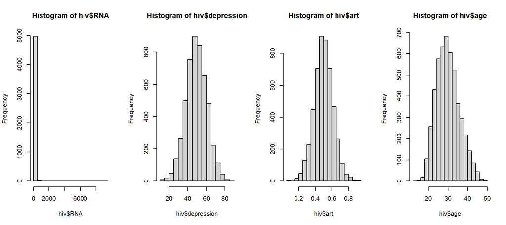

```r
# Plot descriptive
par(mfrow=c(1,4))
hist(hiv$RNA); hist(hiv$depression); hist(hiv$art); hist(hiv$age)
```

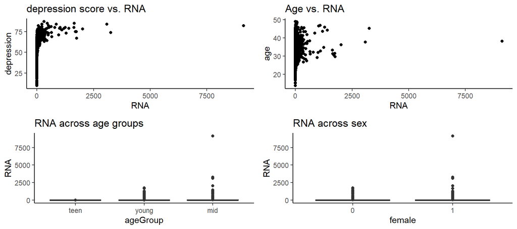

```r
grid.arrange(
  ggplot(data = hiv, aes(x = RNA, y = depression)) + geom_point() + theme_classic() + ggtitle("depression score vs. RNA"),
  ggplot(data = hiv, aes(x = RNA, y = age)) + geom_point() + theme_classic() + ggtitle("Age vs. RNA"),
  ggplot(data = hiv, aes(  ageGroup, RNA))  + geom_boxplot() + theme_classic() + ggtitle("RNA across age groups"),
  ggplot(data = hiv, aes(  female, RNA))  + geom_boxplot() + theme_classic()  + ggtitle("RNA across sex")
)
```

# First, go through the codes for least square estimation before working on Questions 1-7 about interpretation.

The estimation can be achive by the calculation of SSxy, SSxx, $\overline{y}$, and $\overline{x}$ manually, or  
Alternatively, R code `lm` can be used as below. To estimate betas, write `lm(outcome ~ exposure, data= data)`.

Either approach is fine to estimate the model below,

$y = \beta_0 + \beta_1 \times x + \epsilon$

Estimate the beta coefficients (parameters)  
$\beta_0, \beta_1$ and once find these, then find the values of “y hat” (fitted, estimated y) as  
$\hat{y} = \hat{\beta_0} + \hat{\beta_1} \times x$  
Then estimate errors $\epsilon$ as  
$\hat{e} = y - \hat{y}$, for each data point.

```r
x <- hiv$RNA
y <- hiv$depression

# Least square estimation
# Beta_1
SS_xy <- sum((x - mean(x))*(y - mean(y)))
SS_xx <- sum((x - mean(x))^2)
beta_1 <- SS_xy/SS_xx
beta_1
```

```
## [1] 0.01440641
```

```r
# Beta_0
mean(y) - beta_1*mean(x)
```

```
## [1] 49.58178
```

```r
beta_0 <- mean(y) - beta_1*mean(x)
beta_0
```

```
## [1] 49.58178
```

```r
# A quicker way to fit - Linear regression function
modelFit <- lm(y ~ x)
# display beta coefficients
modelFit$coefficients
```

```
## (Intercept)           x
## 49.58177637  0.01440641
```

```r
# y hat (estiamted, fitted outcome)
head(modelFit$fitted.values)
```

```
##        1        2        3        4        5        6
## 49.58621 49.79980 49.58316 49.59801 49.58411 51.14545
```

```r
# Error, y minus y hat
head(hiv$depression) - head(modelFit$fitted.values)
```

```
##          1          2          3          4          5          6
## -0.5862136 13.2002039 -8.5831613  0.4019943 -4.5841085 15.8545486
```

```r
# And so, sum of squared error,  SSE(beta_0, beta_1) is....
sum((hiv$depression - modelFit$fitted.values)^2)
```

```
## [1] 596311.1
```

```r
# Additionally, SSyy
SSyy <- sum(hiv$depression - mean(hiv$depression)^2)

# Correlation (recall addition of Random Variable Part 2-3, to be covered again later)
cor(hiv$RNA, hiv$depression)
```

```
## [1] 0.2175085
```

```r
(SS_xy / 5000)/(sd(hiv$RNA)*sd(hiv$depression)) # manual calculation for correlation
```

```
## [1] 0.217465
```

# Question 1. Plot variables, log transformed

### Task: Plot the same images as above after transforming RNA

Either log base 2, 10, or natural log is fine

# Question 2. Compute a 95% Confidence Interval for mean RNA.

### Task: Answer: How appropriate is your test of choice for data with such a strong skewness?

```r
  # Question 2 - 95% CI or significance test...null is mu = 0
  t.test(hiv$RNA, mu = 0)
```

```
##
##  One Sample t-test
##
## data:  hiv$RNA
## t = 7.659, df = 4999, p-value = 2.235e-14
## alternative hypothesis: true mean is not equal to 0
## 95 percent confidence interval:
##  13.61515 22.98295
## sample estimates:
## mean of x
##  18.29905
```

# Question 3: Fit the model on the original (untransformed) RNA variable and interpret

### Task: Write the corresponding equation to the linear model and fill the Excel answer sheet

### Task: Interpret $\beta_0$ and $\beta_1$. Again, enter your interpretations in the Excel sheet

### Task: Plot the error and evaluate whether it follows a normal distribution or not

```r
#QUESTION 3: Write an equation and interpret beta_0 and beta_1
fitRNA <- lm(depression~RNA, data = hiv)
summary(fitRNA)
```

```
##
## Call:
## lm(formula = depression ~ RNA, data = hiv)
##
## Residuals:
##     Min      1Q  Median      3Q     Max
## -99.018  -7.582   0.379   7.390  32.852
##
## Coefficients:
##              Estimate Std. Error t value Pr(>|t|)
## (Intercept) 4.958e+01  1.554e-01  319.11   <2e-16 ***
## RNA         1.441e-02  9.144e-04   15.75   <2e-16 ***
## ---
## Signif. codes:  0 '***' 0.001 '**' 0.01 '*' 0.05 '.' 0.1 ' ' 1
##
## Residual standard error: 10.92 on 4998 degrees of freedom
## Multiple R-squared:  0.04731,    Adjusted R-squared:  0.04712
## F-statistic: 248.2 on 1 and 4998 DF,  p-value: < 2.2e-16
```

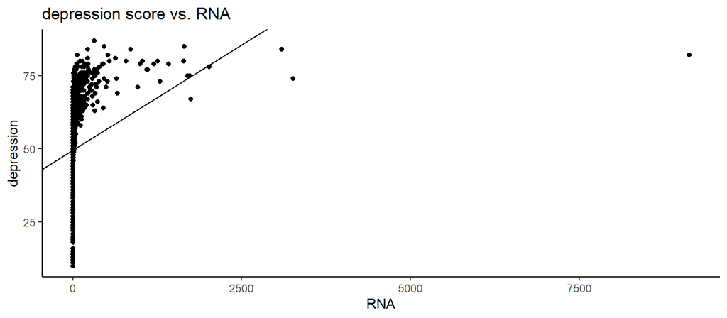

```r
beta_0 <- fitRNA$coefficients["(Intercept)"]
beta_1 <- fitRNA$coefficients["RNA"]
ggplot(data = hiv, aes(x = RNA, y = depression)) +
  geom_point() +
  theme_classic() +
  ggtitle("depression score vs. RNA") +
  geom_abline(slope = beta_1, intercept = beta_0)
```

#### Plots

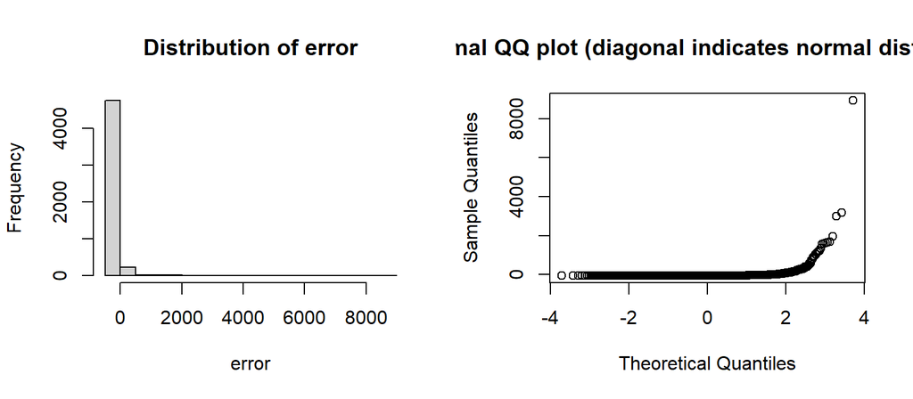

```r
#QUESTION 4:  Plot an error , to see if they form normal distribution or not
error <- hiv$RNA - fitRNA$fitted.values
par(mfrow = c(1,2))
hist(error, main = "Distribution of error")
qqnorm(error, main = "normal QQ plot (diagonal indicates normal distribution")
```

```r
par(mfrow = c(1,1))
```

# Question 4-1 (natural log): Fit the model on the *Natural log transformed* RNA exposure

### Write the corresponding equation and fill the Excel answer sheet

```r
# Fit the model
fitRNA <- lm(depression~RNAe, data = hiv)
summary(fitRNA)
```

```
##
## Call:
## lm(formula = depression ~ RNAe, data = hiv)
##
## Residuals:
##      Min       1Q   Median       3Q      Max
## -15.9474  -3.4031  -0.0965   3.4487  19.7152
##
## Coefficients:
##             Estimate Std. Error t value Pr(>|t|)
## (Intercept) 49.93547    0.07069   706.4   <2e-16 ***
## RNAe         4.18149    0.02953   141.6   <2e-16 ***
## ---
## Signif. codes:  0 '***' 0.001 '**' 0.01 '*' 0.05 '.' 0.1 ' ' 1
##
## Residual standard error: 4.999 on 4998 degrees of freedom
## Multiple R-squared:  0.8005, Adjusted R-squared:  0.8004
## F-statistic: 2.005e+04 on 1 and 4998 DF,  p-value: < 2.2e-16
```

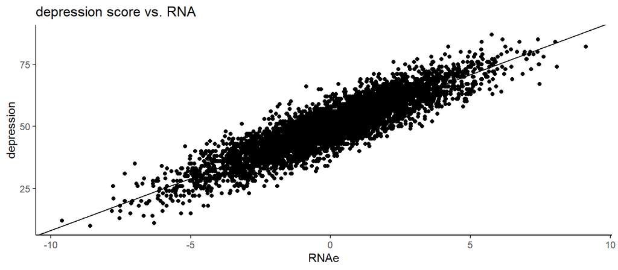

```r
beta_0 <- fitRNA$coefficients["(Intercept)"] %>% unname()
beta_1 <- fitRNA$coefficients["RNAe"] %>% unname()
ggplot(data = hiv, aes(x = RNAe, y = depression)) +
  geom_point() +
  theme_classic() +
  ggtitle("depression score vs. RNA") +
  geom_abline(slope = beta_1, intercept = beta_0)
```

### Plots

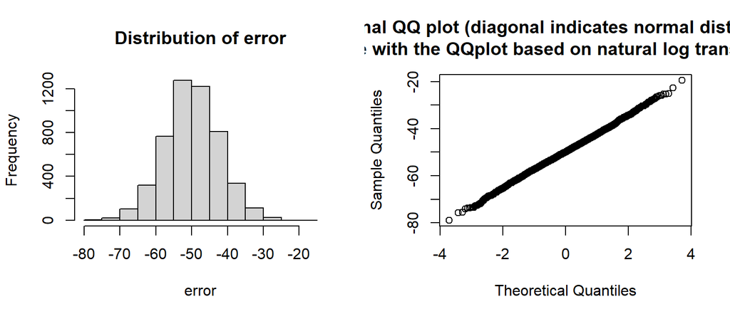

```r
#QUESTION 6:  Plot an error , to see if they form normal distribution or not
error <- hiv$RNAe - fitRNA$fitted.values
par(mfrow = c(1,2))
hist(error, main = "Distribution of error")
qqnorm(error, main = "normal QQ plot (diagonal indicates normal distribution \n compare with the QQplot based on natural log transformed RNA")
```

```r
par(mfrow = c(1,1))
```

# Question 4-2 (natural log): Interpret $\beta_1$, additive (1 unit increase) vs. multiplicative (% increase)

### Write the two versions of interpretation in the Excel answer sheet, with and without log transformation of RNA

As you can see below, when log transformed, beta no longer has a linear interpretation i.e., when converted to the none-log scale, the change of $y$ in response to the increase of x by 1 unit depends on the value of $x$ and no longer fixed across all values of x. However, it is fixed if the change of x is 1% increase, rather than 1 unit increas. See below.

```r
# Interpretation in the non-log scale, 1% increase of x has fixed value of beta_1
{beta_0 + beta_1*log(1.01)} - {beta_0 + beta_1*log(1)}
{beta_0 + beta_1*log(5.05)} - {beta_0 + beta_1*log(5)}
{beta_0 + beta_1*log(10.1)} - {beta_0 + beta_1*log(10)}
{beta_0 + beta_1*log(15.15)} - {beta_0 + beta_1*log(15)}



# interpretation in the log scale, 1.0 unit increase has constant value
{beta_0 + beta_1*11} - {beta_0 + beta_1*10}
{beta_0 + beta_1*21} - {beta_0 + beta_1*20}
{beta_0 + beta_1*61} - {beta_0 + beta_1*60}
{beta_0 + beta_1*101} - {beta_0 + beta_1*100}
{beta_0 + beta_1*301} - {beta_0 + beta_1*300}
```

[output not shown]

# Question 5-1 (log base 2) : Fit the model on the *log base 2 transformed* RNA exposure

### Write the equation in the Excel sheet again

```r
#  Fit the model
fitRNA <- lm(depression~RNA2, data = hiv)
summary(fitRNA)
```

```
##
## Call:
## lm(formula = depression ~ RNA2, data = hiv)
##
## Residuals:
##      Min       1Q   Median       3Q      Max
## -15.9474  -3.4031  -0.0965   3.4487  19.7152
##
## Coefficients:
##             Estimate Std. Error t value Pr(>|t|)
## (Intercept) 49.93547    0.07069   706.4   <2e-16 ***
## RNA2         2.89839    0.02047   141.6   <2e-16 ***
## ---
## Signif. codes:  0 '***' 0.001 '**' 0.01 '*' 0.05 '.' 0.1 ' ' 1
##
## Residual standard error: 4.999 on 4998 degrees of freedom
## Multiple R-squared:  0.8005, Adjusted R-squared:  0.8004
## F-statistic: 2.005e+04 on 1 and 4998 DF,  p-value: < 2.2e-16
```

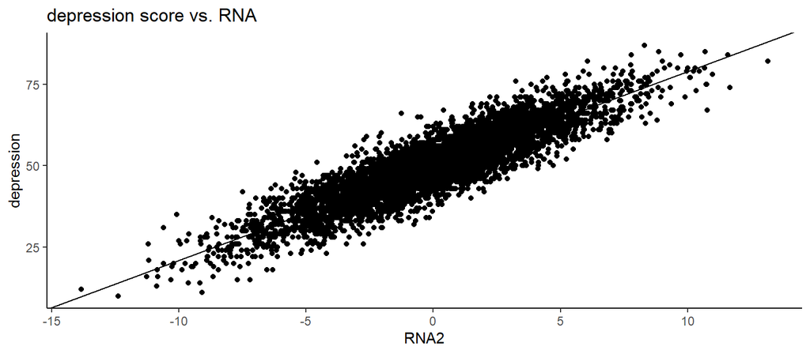

```r
beta_0 <- fitRNA$coefficients["(Intercept)"]
beta_1 <- fitRNA$coefficients["RNA2"]
ggplot(data = hiv, aes(x = RNA2, y = depression)) +
  geom_point() +
  theme_classic() +
  ggtitle("depression score vs. RNA") +
  geom_abline(slope = beta_1, intercept = beta_0)
```

#### Plots

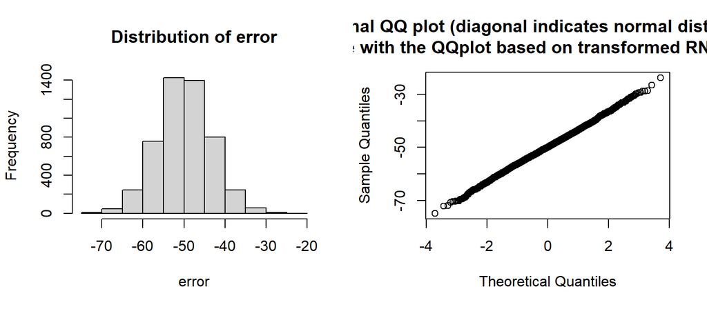

```r
# Plot error, to see if they form normal distribution or not
error <- hiv$RNA2 - fitRNA$fitted.values
par(mfrow = c(1,2))
hist(error, main = "Distribution of error")
qqnorm(error, main = "normal QQ plot (diagonal indicates normal distribution \n compare with the QQplot based on transformed RNA, log base 2")
```

```r
par(mfrow = c(1,1))
```

# Additional information about the interpretation of $\beta_1$ (log base 2) :

Compare the model-estimated slope between *log base 2* transformed RNA above vs. the observed trend computed below (they wont’ completely agree, since the mostl is not perfect fit)

```r
hiv$lowRNA <- ifelse((hiv$RNA>.5 & hiv$RNA<1.5),1,0)
table(hiv$lowRNA)
```

```
##
##    0    1
## 4058  942
```

```r
hiv$medRNA <- ifelse((hiv$RNA>1.5 & hiv$RNA<2.5),1,0)
table(hiv$medRNA)
```

```
##
##    0    1
## 4611  389
```

```r
mean(hiv$depression[hiv$medRNA==1])-mean(hiv$depression[hiv$lowRNA==1])
```

```
## [1] 3.218138
```

```r
## Let's look at average depression in people with
## RNA~=2 vs RNA~=4
hiv$medRNA <- ifelse((hiv$RNA>1.5 & hiv$RNA<2.5),1,0)
table(hiv$medRNA)
```

```
##
##    0    1
## 4611  389
```

```r
hiv$hiRNA <- ifelse((hiv$RNA>3.5 & hiv$RNA<4.5),1,0)
table(hiv$hiRNA)
```

```
##
##    0    1
## 4815  185
```

```r
mean(hiv$depression[hiv$hiRNA==1])-mean(hiv$depression[hiv$medRNA==1])
```

```
## [1] 3.247565
```

# Question 5-2 (log base 2) : Interpretation

### Write the two versions of interpretation in the Excel answer sheet, with and without log base 2 transformation of RNA

As before, when x is log base 2 transformed, $\beta_1$ no longer has a linear interpretation, i.e., when converted to the none-log scale, the change of $y$ in response to the increase of x by 1 unit depends on the value of $x$ and no longer fixed across all values of x. However, it is fixed if the change of x double, rather than 1 unit increase. See codes below that show, when log transformed with base 2, $\beta_1$ has fixed value only when interpreted based on the transformed scale. If converted back to non-log by $2^x$, the change of $y$ in response to the increase of x by 2 folds, not by 1 unit.

```r
# 1 Unit increase , in non-log scale. Beta_1 has no constant meaning in one unit increase in the non-log scale
x<-1
{beta_0 + beta_1*2^(x + 1)} - {beta_0 + beta_1*2^(x)}
x<-2
{beta_0 + beta_1*2^(x + 1)} - {beta_0 + beta_1*2^(x)}
x<-3
{beta_0 + beta_1*2^(x + 1)} - {beta_0 + beta_1*2^(x)}


# However, if x is doubled, beta_1 offer a constant increase of y in the non-log scale
x<-1
{beta_0 + beta_1*log2(2*x)} - {beta_0 + beta_1*log2(x)} # x= 2 vs 1
x<-2
{beta_0 + beta_1*log2(2*x)} - {beta_0 + beta_1*log2(x)} # x= 4 vs 2
x<-3
{beta_0 + beta_1*log2(2*x)} - {beta_0 + beta_1*log2(x)} # x= 6 vs 3


# interpretation in the log scale, 1.0 unit increase has constant value as usual
{beta_0 + beta_1*11} - {beta_0 + beta_1*10}
{beta_0 + beta_1*21} - {beta_0 + beta_1*20}
{beta_0 + beta_1*61} - {beta_0 + beta_1*60}
{beta_0 + beta_1*101} - {beta_0 + beta_1*100}
{beta_0 + beta_1*301} - {beta_0 + beta_1*300}
```

[output not shown]

# Question 6: Interpretation of the intercept.

### This time, the exposure is Age and the outcome (response variable) is depression score.

### Be careful about the range of Age in the original data. Do not over-interpret $\beta_0$. If necessary, standardize the values of x.

### Write the corresponding equation

### Interpret $\beta_0$, that is, what is the meaning of $\hat{y} = \hat{\beta_0} + \hat{\beta_1} \times x$, where $x = 0$?

```r
#  Fit the model
fitAge <- lm(depression~age, data = hiv)
summary(fitAge)
```

```
##
## Call:
## lm(formula = depression ~ age, data = hiv)
##
## Residuals:
##     Min      1Q  Median      3Q     Max
## -37.145  -6.880  -0.073   7.132  36.275
##
## Coefficients:
##             Estimate Std. Error t value Pr(>|t|)
## (Intercept) 29.50992    0.77145   38.25   <2e-16 ***
## age          0.68065    0.02534   26.86   <2e-16 ***
## ---
## Signif. codes:  0 '***' 0.001 '**' 0.01 '*' 0.05 '.' 0.1 ' ' 1
##
## Residual standard error: 10.46 on 4998 degrees of freedom
## Multiple R-squared:  0.1261, Adjusted R-squared:  0.126
## F-statistic: 721.4 on 1 and 4998 DF,  p-value: < 2.2e-16
```

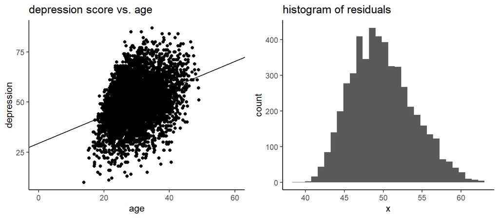

```r
beta_0 <- fitAge$coefficients["(Intercept)"]
beta_1 <- fitAge$coefficients["age"]

grid.arrange(
  ggplot(data = hiv, aes(x = age, y = depression)) +
    geom_point() +
    theme_classic() +
    ggtitle("depression score vs. age") +
    geom_abline(slope = beta_1, intercept = beta_0) +
    xlim(c(0,60)),
  ggplot(data.frame(x = fitAge$fitted.values), aes(x)) +
    geom_histogram() +
    theme_classic() +
    ggtitle("histogram of residuals"),
  ncol = 2
)
```

### What is wrong with the value of $\beta_0$ here?

```r
hiv$age_center <- hiv$age - mean(hiv$age)
#  Fit the model
fitAge_center <- lm(depression~age_center, data = hiv)
summary(fitAge_center)
```

```
##
## Call:
## lm(formula = depression ~ age_center, data = hiv)
##
## Residuals:
##     Min      1Q  Median      3Q     Max
## -37.145  -6.880  -0.073   7.132  36.275
##
## Coefficients:
##             Estimate Std. Error t value Pr(>|t|)
## (Intercept) 49.84540    0.14795  336.92   <2e-16 ***
## age_center   0.68065    0.02534   26.86   <2e-16 ***
## ---
## Signif. codes:  0 '***' 0.001 '**' 0.01 '*' 0.05 '.' 0.1 ' ' 1
##
## Residual standard error: 10.46 on 4998 degrees of freedom
## Multiple R-squared:  0.1261, Adjusted R-squared:  0.126
## F-statistic: 721.4 on 1 and 4998 DF,  p-value: < 2.2e-16
```

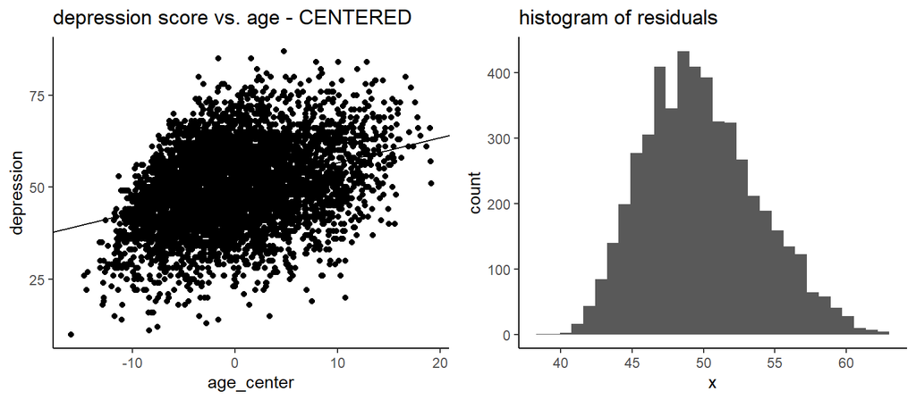

```r
beta_0 <- fitAge_center$coefficients["(Intercept)"]
beta_1 <- fitAge_center$coefficients["age_center"]

grid.arrange(
  ggplot(data = hiv, aes(x = age_center, y = depression)) +
    geom_point() +
    theme_classic() +
    ggtitle("depression score vs. age - CENTERED") +
    geom_abline(slope = beta_1, intercept = beta_0),
  ggplot(data.frame(x = fitAge$fitted.values), aes(x)) +
    geom_histogram() +
    theme_classic() +
    ggtitle("histogram of residuals"),
  ncol = 2
)
```